# Project 5: Does body temperature vary in human subjects according to activity level?

Lauren Geary, Julia Curry, Conor Booth, Weihang Huang

2023-10-04

# Introduction

### Body Temperature Responses to Exercise

According to Neves et al. (2015), during low intensity aerobic exercise, skin temperature over both the active and inactive muscles decreases and returning to normal values a few minutes after rest. This finding is counter intuitive, because according to Sawka et al. (1993), core temperature initially increases rapidly and subsequently increases at a reduced rate until heat loss equals heat production during exercise. Thus, this project will investigate on the topic of whether body temperature varies in human subjects according to activity level.

# Results

DS18B20 Sensor is used to collect the body temperature data and then data of body temperature from the active and inactive conditions for all group members is combined into one table and them plotted the data for comparison.

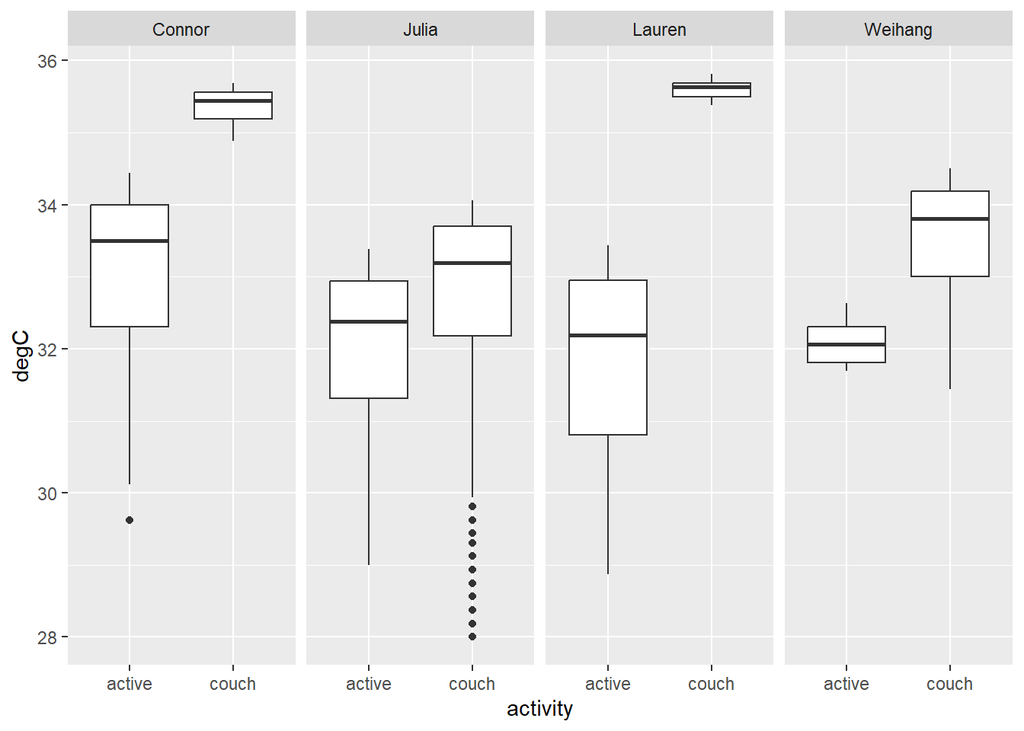

From the plot, it’s clear that the body temperature during active state is lower than the body temperature during couch state for all four of our group members.

# Discussion

The results is consistent with the findings from the paper Neves et al. (2015) that the skin temperature decreases instead of increases after exercise. Our first hypothesis to explain the decrease in skin temperature is that the evaporating cooling is enhanced during exercise. However, according to Neves et al. (2015), fall in skin temperature during initial exercise was not due to increased cooling by evaporation, but by vascular-constriction, probably caused by non-thermal factors.

To investigate on the effect of level of activity on the *core* temperature of human, more advanced equipment and better experimental design is needed.

# Author Contributions

### Julia Curry

Combined all the data from the group into one table. Found and cited a study in the introduction that explains “Core Temperature Responses to Exercise”.

### Conor Booth

Proof reading and final touches.

### Lauren Geary

Generated .csv files with group data of active and inactive conditions. Produced box plots.

### Weihang Huang

Created the bibliography text file and modified the introduction wrote by Julia. Wrote the discussion session.

# References

Neves, Eduardo B., José Vilaça-Alves, Natacha Antunes, Ivo M. V. Felisberto, Claudio Rosa, and Victor M. Reis. 2015. “Different Responses of the Skin Temperature to Physical Exercise: Systematic Review.” In *2015 37th Annual International Conference of the IEEE Engineering in Medicine and Biology Society (EMBC)*, 1307–10. https://doi.org/10.1109/EMBC.2015.7318608.

Sawka, Michael N, C Bruce Wenger, Andrew J Young, and Kent B Pandolf. 1993. “Physiological Responses to Exercise in the Heat.” *Nutritional Needs in Hot Environments: Applications for Military Personnel in Field Operations* 55.